# Project 1-Jake Brophy, Zak Lang, James Chen, Wooin Lee

Jake Brophy, Zak Lang, James Chen, Wooin Lee

10/11/2021

Data explanation: A collection of Airbnb properties across the US, we have chosen to try and use the data provided to model which factors affect the price of an airbnb.

Variables:

price: The price of the Airbnb per night

number_of_reviews: The number of reviews on a listing

review_scores_value: The average review rating on a listing from 0-10 (10 being the best score)

cancellation_policy: The cancellation policy rated on how many days ahead of the stay you have to cancel for a full refund

host_for_x_days: How long the host has been listing their Airbnb

host_response_rate: Percent of time that the host responds to customers

accommodates: Number of people that can stay at the Airbnb

security_deposit: The price customers pay to Airbnb to secure their room

cleaning_fee: The price Airbnb charges to customers for cleaning fee

minimum_nights: The minimum nights customers can stay

maximum_nights: The maximum nights customers can stay

Setup:

## R Markdown

Question 1: analysis

```r
library('tidyverse')
par(mfrow = (c(3,3)))
library(MASS)
```

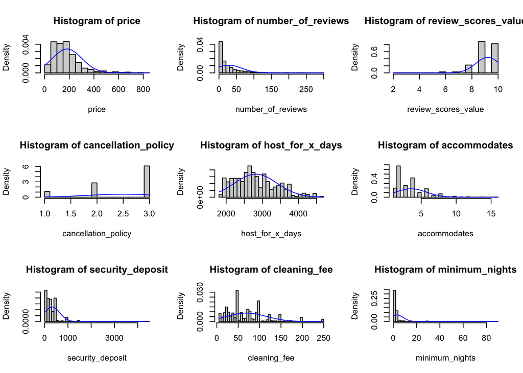

```r
fit <- fitdistr(price, densfun="normal")
hist(price, pch=20, breaks=25, prob = TRUE)
curve(dnorm(x, fit$estimate[1], fit$estimate[2]), col="blue", add=T)

fit2 <- fitdistr(number_of_reviews, densfun="normal")
hist(number_of_reviews, pch=20, breaks=25, prob = TRUE)
curve(dnorm(x, fit2$estimate[1], fit2$estimate[2]), col="blue", add=T)


fit3 <- fitdistr(review_scores_value, densfun="normal")
hist(review_scores_value, pch=20, breaks=25, prob = TRUE)
curve(dnorm(x, fit3$estimate[1], fit3$estimate[2]), col="blue", add=T)


fit4 <- fitdistr(cancellation_policy, densfun="normal")
hist(cancellation_policy, pch=20, breaks=25, prob = TRUE)
curve(dnorm(x, fit4$estimate[1], fit4$estimate[2]), col="blue", add=T)


fit5 <- fitdistr(host_for_x_days, densfun="normal")
hist(host_for_x_days, pch=30, breaks=40, prob = TRUE)
curve(dnorm(x, fit5$estimate[1], fit5$estimate[2]), col="blue", add=T)


fit6 <- fitdistr(accommodates, densfun="normal")
hist(accommodates, pch=30, breaks=40, prob = TRUE)
curve(dnorm(x, fit6$estimate[1], fit6$estimate[2]), col="blue", add=T)


fit7 <- fitdistr(security_deposit, densfun="normal")
hist(security_deposit, pch=30, breaks=40, prob = TRUE)
curve(dnorm(x, fit7$estimate[1], fit7$estimate[2]), col="blue", add=T)


fit8 <- fitdistr(cleaning_fee, densfun="normal")
hist(cleaning_fee, pch=30, breaks=40, prob = TRUE)
curve(dnorm(x, fit8$estimate[1], fit8$estimate[2]), col="blue", add=T)


fit9 <- fitdistr(minimum_nights, densfun="normal")
hist(minimum_nights, pch=30, breaks=40, prob = TRUE)
curve(dnorm(x, fit9$estimate[1], fit9$estimate[2]), col="blue", add=T)
```

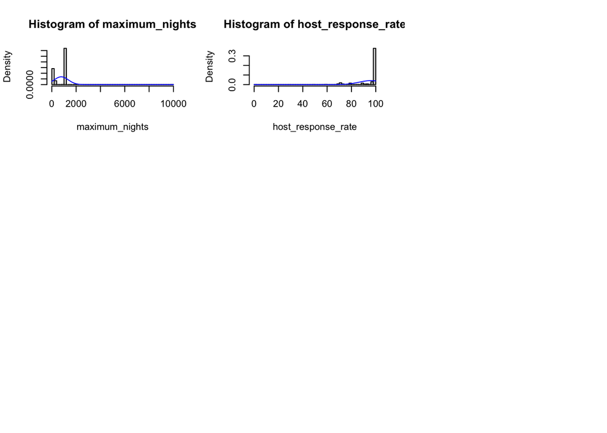

```r
fit10 <- fitdistr(maximum_nights, densfun="normal")
hist(maximum_nights, pch=30, breaks=40, prob = TRUE)
curve(dnorm(x, fit10$estimate[1], fit10$estimate[2]), col="blue", add=T)


fit11 <- fitdistr(host_response_rate, densfun="normal")
hist(host_response_rate, pch=30, breaks=40, prob = TRUE)
curve(dnorm(x, fit11$estimate[1], fit11$estimate[2]), col="blue", add=T)
```

The majority of prices are clustered around $100-$200 dollars, with more expensive properties reaching upwards of $800-$1000

From this plot we can see that the majority of people leave good reviews for the rentals they stay at, with the average being around a 9

From this we can see most properties have a cancellation policy of 3, suggesting that most have a fairly strict cancellation policy

There is a fairly equal distribution of how long a person has been a host for those who have been hosting 2000-3000 dayswith a drop off after that, with very few hosts having worked for more than 4000 days

We can see that most properties don’t offer many accomodates, which could possibly suggest that those who do offer accomodates will be able to charge more

The range of security deposit seems to be narrow, with the vast majority being less than $1000

The most prevelant cleaning fee was around $50, with a fairly equal distribution until dropping off after $100

0 is also fairly prevalent here, suggesting that many hosts don’t list a maximum night. The second most prevelant is around 1000, which suggests that those who do have a maximum stay nights are probably longer term rentals

Most hosts are very responsive and respond to all the emails they receive

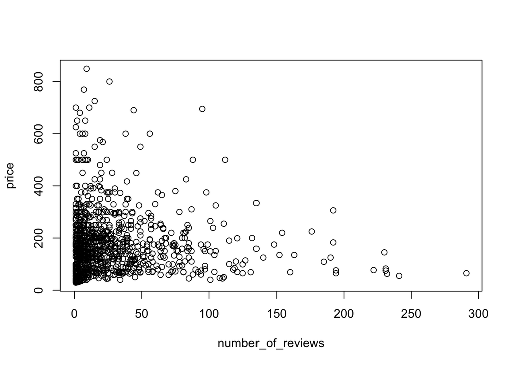

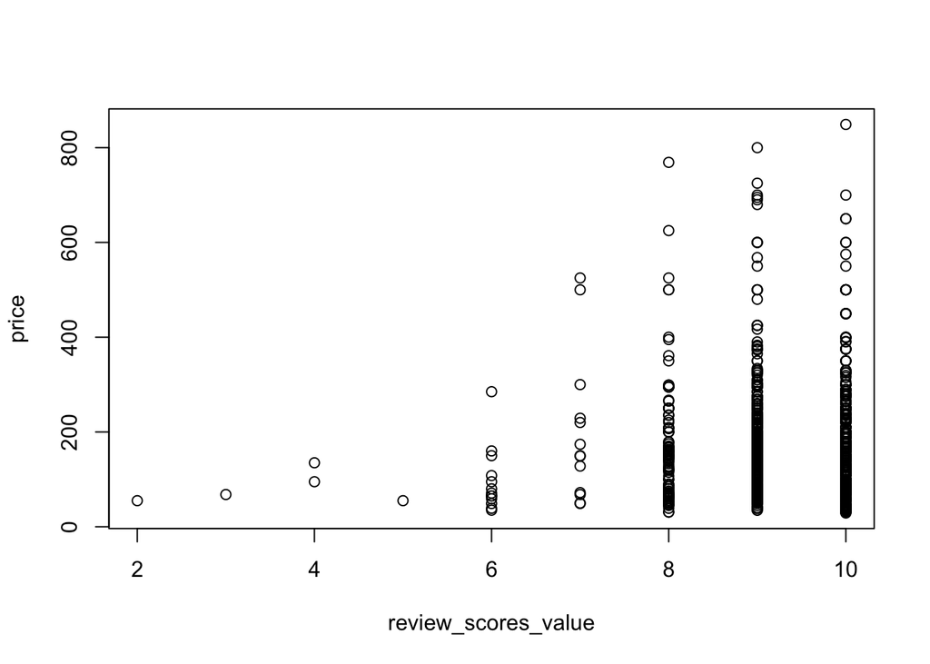

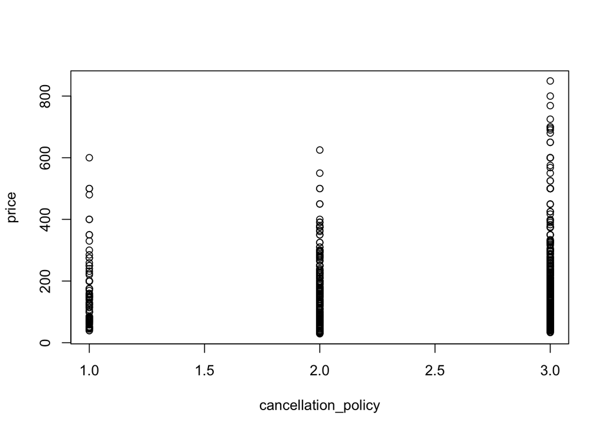

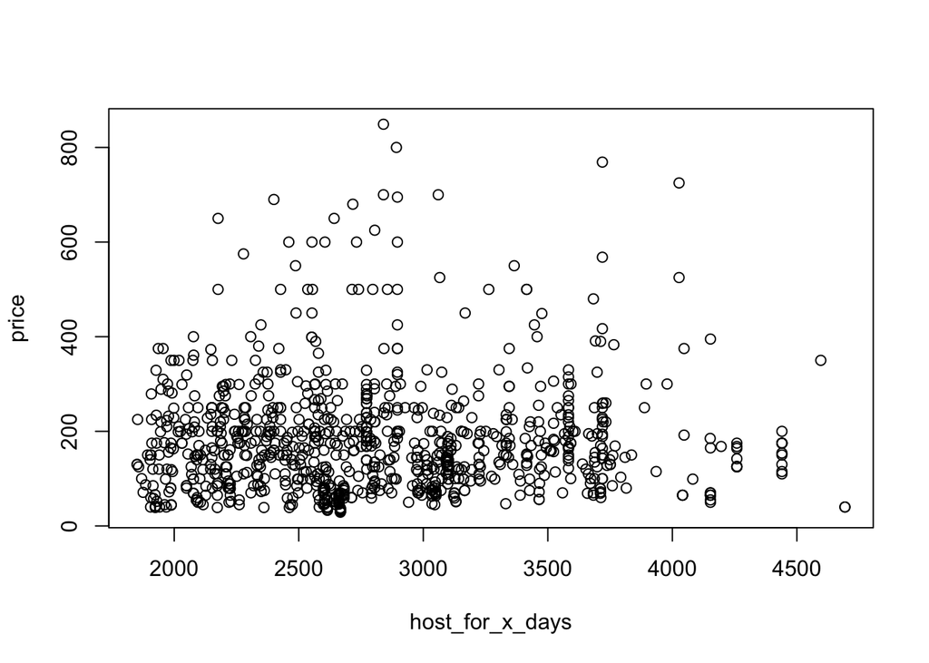

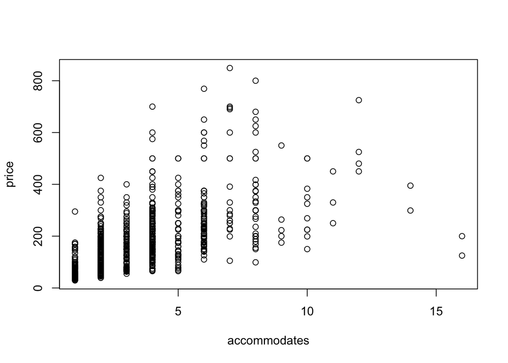

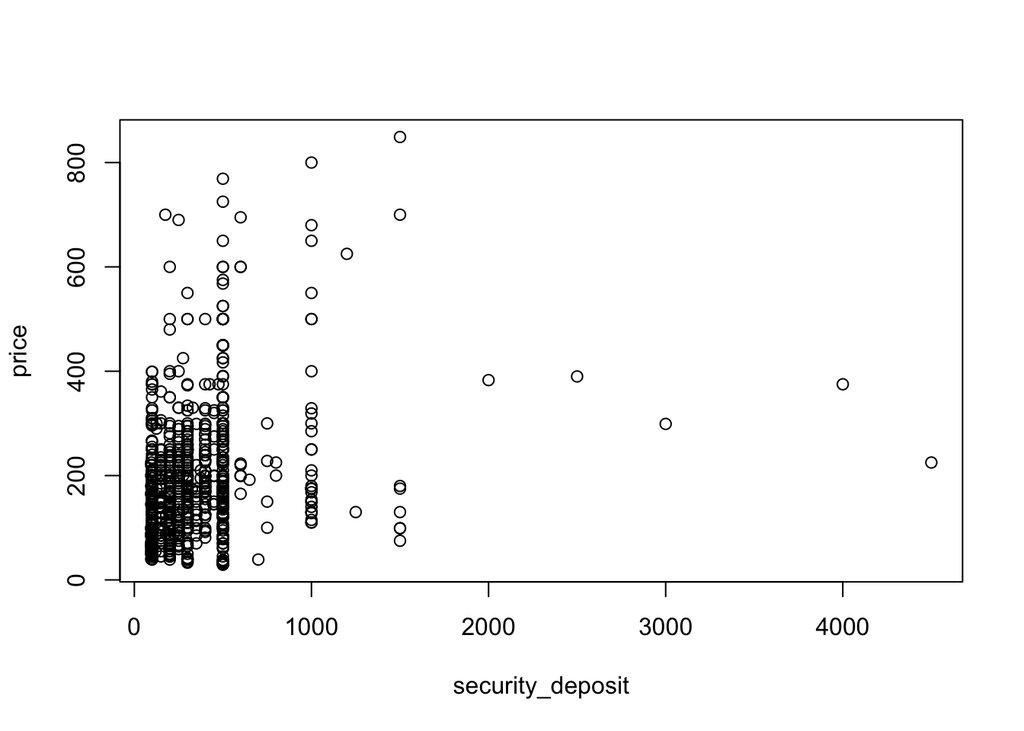

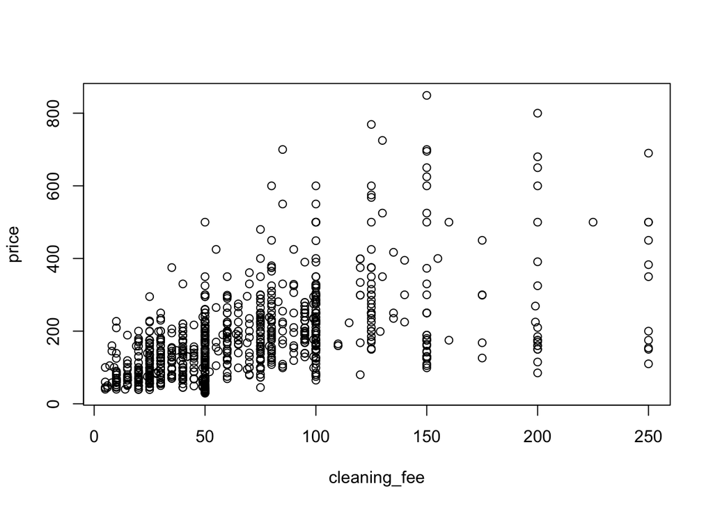

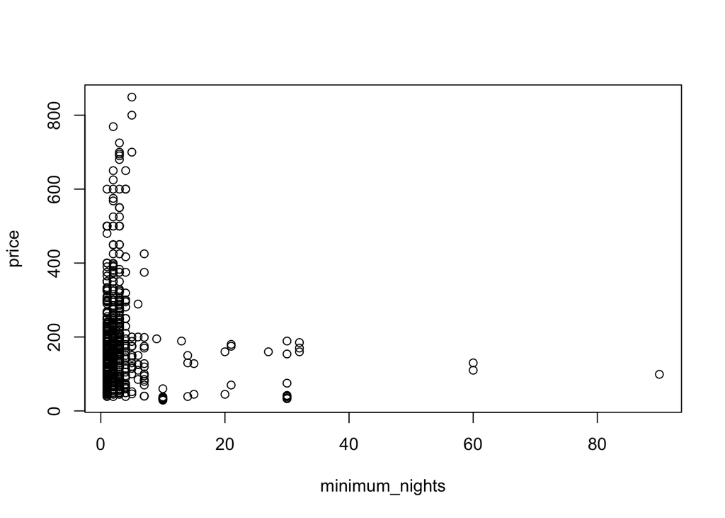

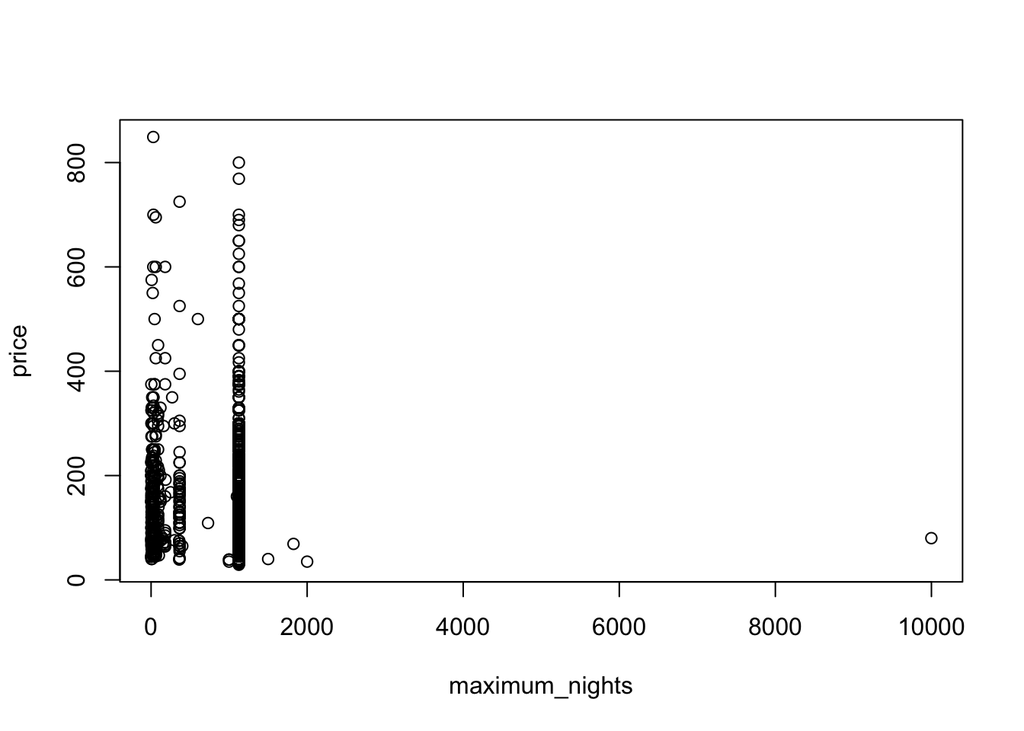

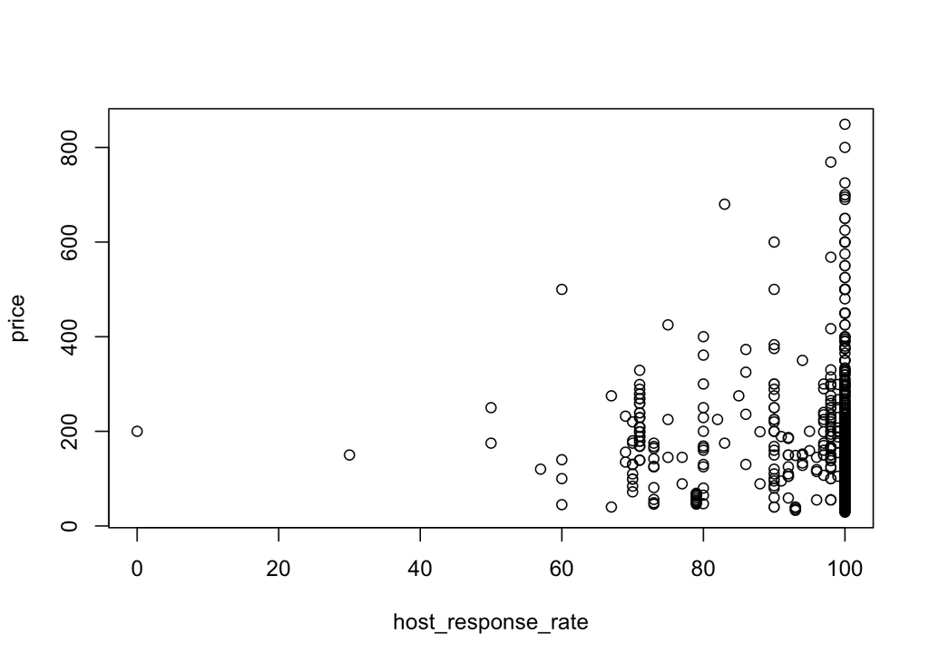

Does not seem to be much correlation between number of reviews and price, heteroscedacticity does seem to be present

There does seem to be some association between the quality of reviews and the price of a property

It seems like the most expensive properties tend to have the highest price

There does not seem to be much of a relationship between price and how long a person has been a host

It seems there is a positive relationship between the number of accomodates and price until there are 7 accomodates present, at which point it becomes more random

Most security deposits fall between $0 and $1000 so there are multiple different prices for any given security deposit

The higher minimum nights properties have the lower their nightly prices tend to be

There does not seem to be much of a relationship between maximum nights and price

There seems to be a positive relationship between price and host response rate

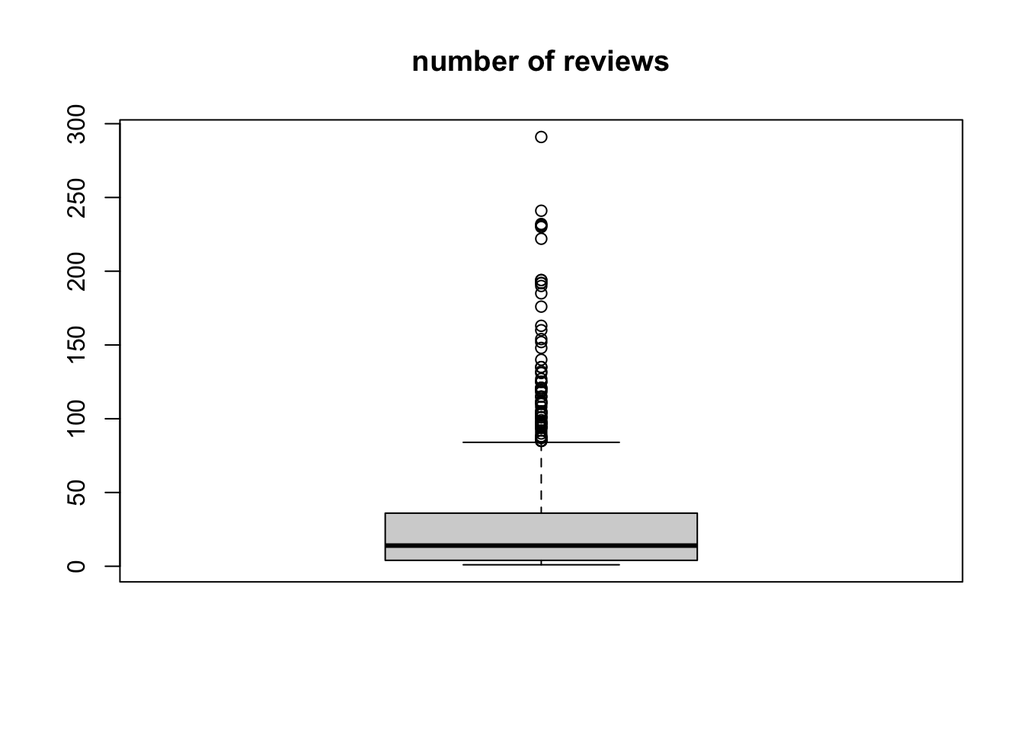

```r
new_data <- subset(data, select = -c(name, host_id, host_name,
                                     host_response_time, property_type, room_type))
boxplot(new_data$number_of_reviews, main = 'number of reviews')
```

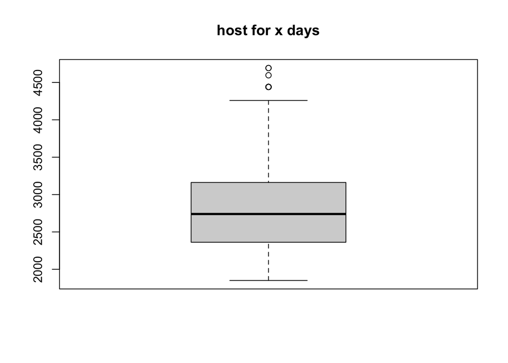

```r
boxplot(new_data$host_for_x_days, main = 'host for x days')
```

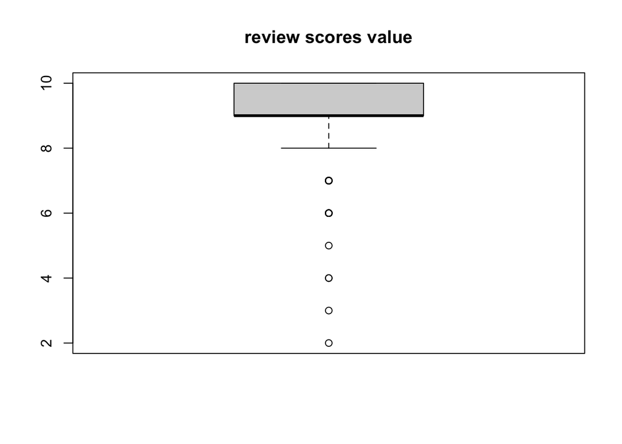

```r
boxplot(new_data$review_scores_value, main = 'review scores value')
```

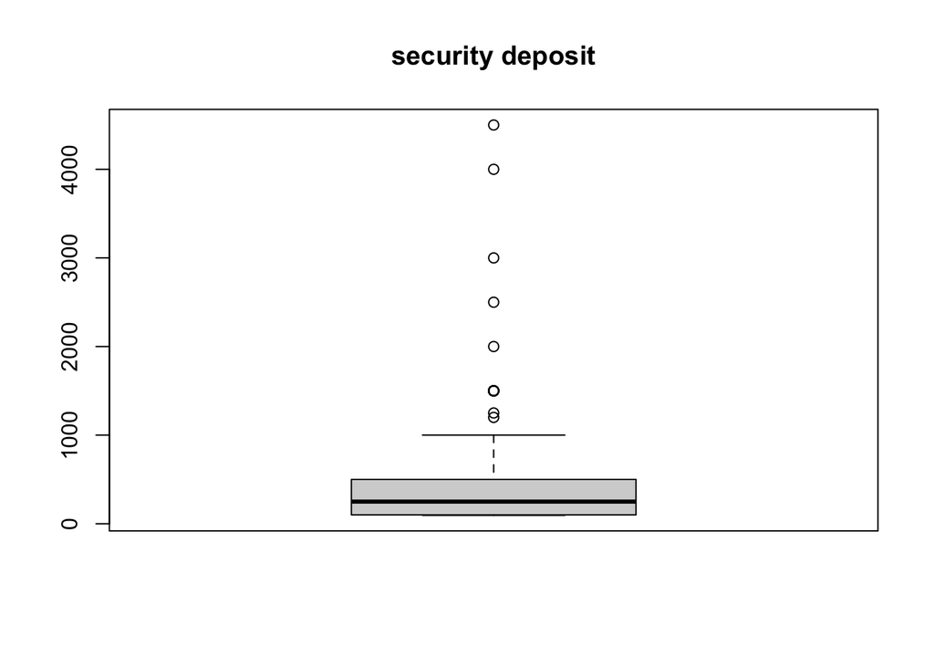

```r
boxplot(new_data$security_deposit, main = 'security deposit')
```

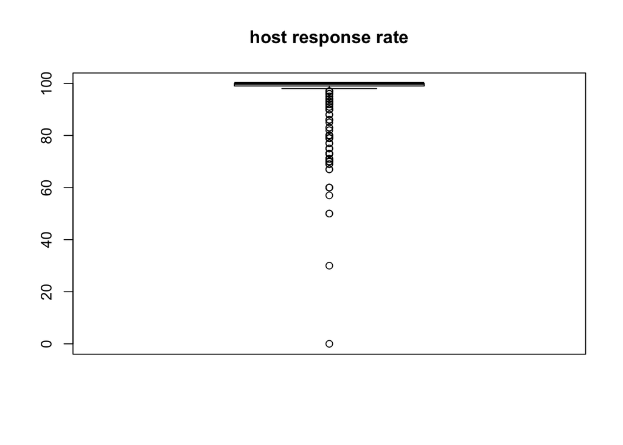

```r
boxplot(new_data$host_response_rate, main = 'host response rate')
```

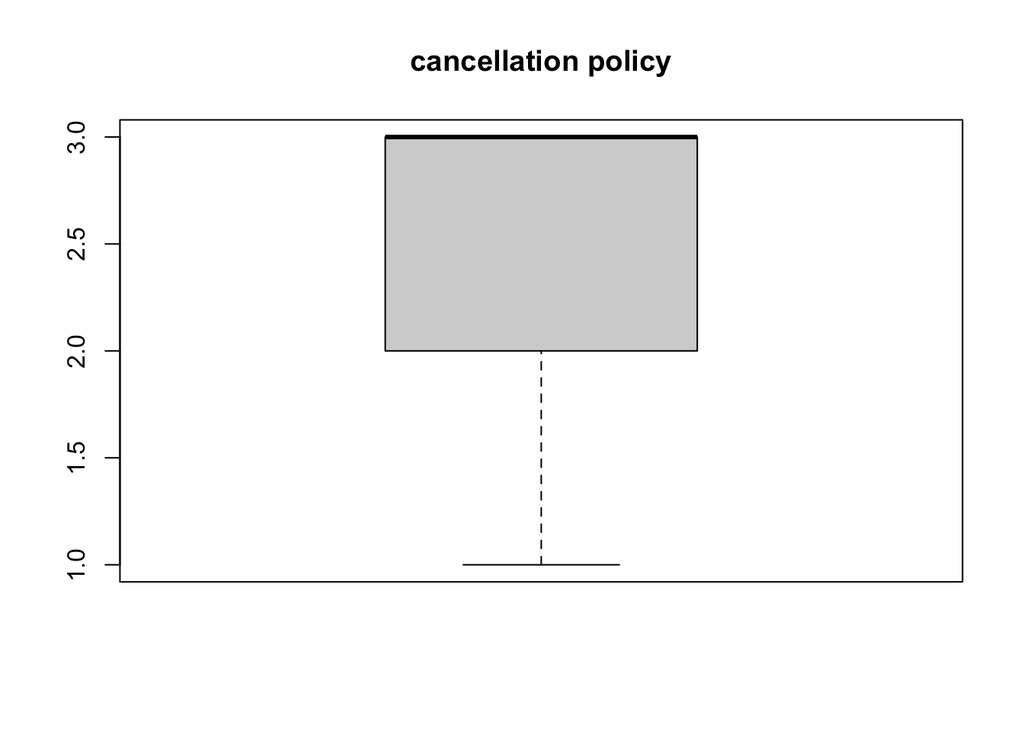

```r
boxplot(new_data$cancellation_policy, main = 'cancellation policy')
```

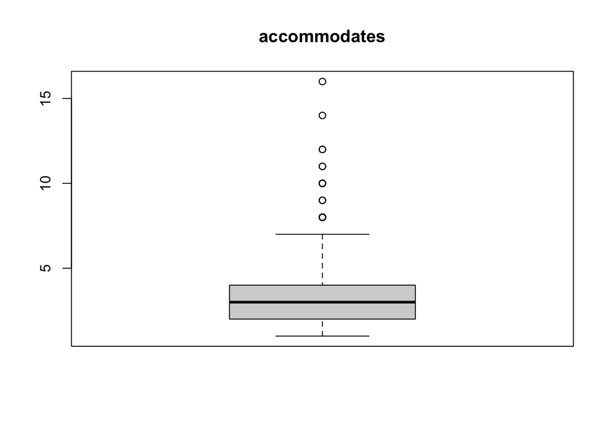

```r
boxplot(new_data$accommodates, main = 'accommodates')
```

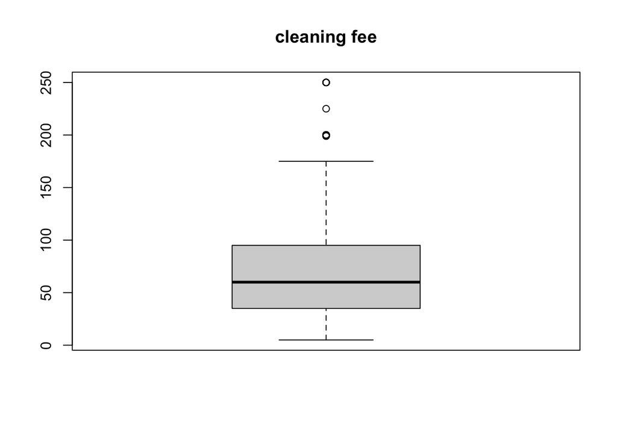

```r
boxplot(new_data$cleaning_fee, main = 'cleaning fee')
```

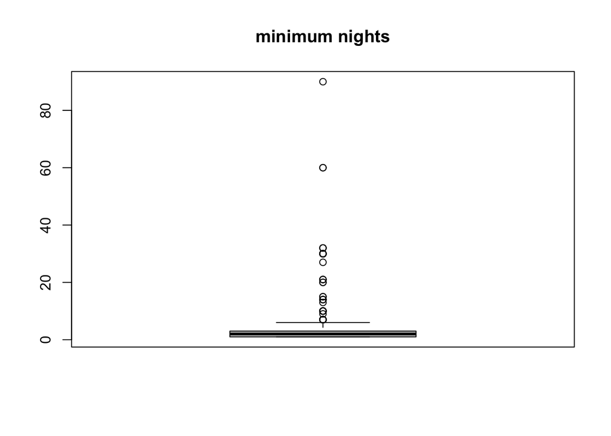

```r
boxplot(new_data$minimum_nights, main = 'minimum nights')
```

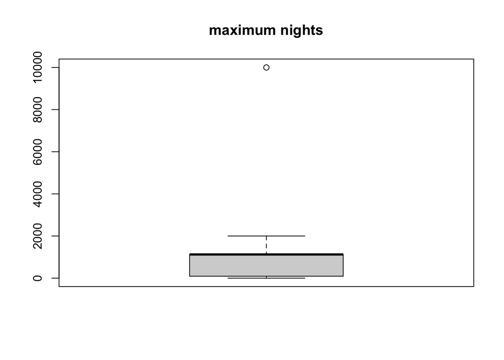

```r
boxplot(new_data$maximum_nights, main = 'maximum nights')
```

number_of_reviews: This boxplot shows some outliers above 100 reviews. However, these are not removed as some places have have been hosting for a while and have a lot of reviews

review_scores_value: Although most Airbnb’s have good reviews, there are some with low reviews and these shouldn’t be eliminated.

cancellation_policy: There are no outliers from this boxplot

host_for_x_days: Some hosts have been hosting for a long time, but these are not errors and the outliers have a particular meaning.

accommodates: Some places are large venues that can host a lot of people. These outliers are important to the model.

cleaning_fee: No outliers are removed, as more expensive places may have greater fees.  
Minimum_nights:The majority of properties have very low or no minimum nights, so those with large minimum nights are outliers and should be removed

maximum_nights: This boxplot shows outliers greater than 8000 nights. These will be removed, as that is a very long time to stay somewhere and doesn’t exactly make sense.

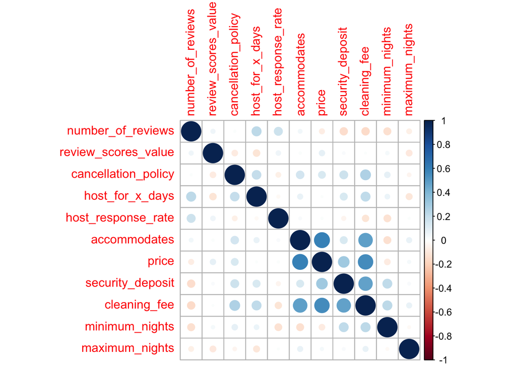

```r
library(corrplot)
library(RColorBrewer)
c <- cor(new_data)
corrplot(c)
```

The variables that seem to be most correlated with price are accomodates, security deposit, and cleaning fee.

Question 2: Baseline model

```r
lmmodel1 <- lm(price ~ number_of_reviews + review_scores_value + cancellation_policy
               +host_for_x_days+accommodates+security_deposit
               +cleaning_fee+minimum_nights+maximum_nights+host_response_rate, data = new_data)
summary(lmmodel1)
```

```
##
## Call:
## lm(formula = price ~ number_of_reviews + review_scores_value +
##     cancellation_policy + host_for_x_days + accommodates + security_deposit +
##     cleaning_fee + minimum_nights + maximum_nights + host_response_rate,
##     data = new_data)
##
## Residuals:
##     Min      1Q  Median      3Q     Max
## -302.26  -45.08  -11.14   38.12  498.47
##
## Coefficients:
##                      Estimate Std. Error t value Pr(>|t|)
## (Intercept)         -9.146895  45.693443  -0.200 0.841384
## number_of_reviews   -0.087861   0.081787  -1.074 0.282982
## review_scores_value  7.579895   3.175557   2.387 0.017188 *
## cancellation_policy -1.733777   4.338747  -0.400 0.689541
## host_for_x_days     -0.018756   0.005208  -3.601 0.000334 ***
## accommodates        21.604091   1.558782  13.860  < 2e-16 ***
## security_deposit     0.044257   0.010114   4.376 1.35e-05 ***
## cleaning_fee         0.934846   0.085918  10.881  < 2e-16 ***
## minimum_nights      -2.945945   0.542416  -5.431 7.15e-08 ***
## maximum_nights      -0.007969   0.004946  -1.611 0.107460
## host_response_rate   0.417366   0.299421   1.394 0.163678
## ---
## Signif. codes:  0 '***' 0.001 '**' 0.01 '*' 0.05 '.' 0.1 ' ' 1
##
## Residual standard error: 86.12 on 928 degrees of freedom
## Multiple R-squared:  0.4883, Adjusted R-squared:  0.4828
## F-statistic: 88.55 on 10 and 928 DF,  p-value: < 2.2e-16
```

From this we can see that the variables that don’t have statistical significance are maximum_nights, host_response_rate, number_of_reviews, and cancellation policy. We can also see that for minimum_nights, host_for_x_days, and number_of_reviews there is a negative coefficient, which means an increase in those variables is associated with a decrease in price that is on average equal to the value of the coefficient. The opposite can be said of the variables with a positive coefficient. We see that the largest estimates were for accommodates and review_scores_value, which makes sense because properties that can fit more accommodates are typically higher end and can charge more so , and the higher a review a property has, the more in demand they likely are and the more they can charge.

Question 3: Outliers

```r
boxplot(new_data$maximum_nights, plot=FALSE)$out
```

```
## [1] 9999
```

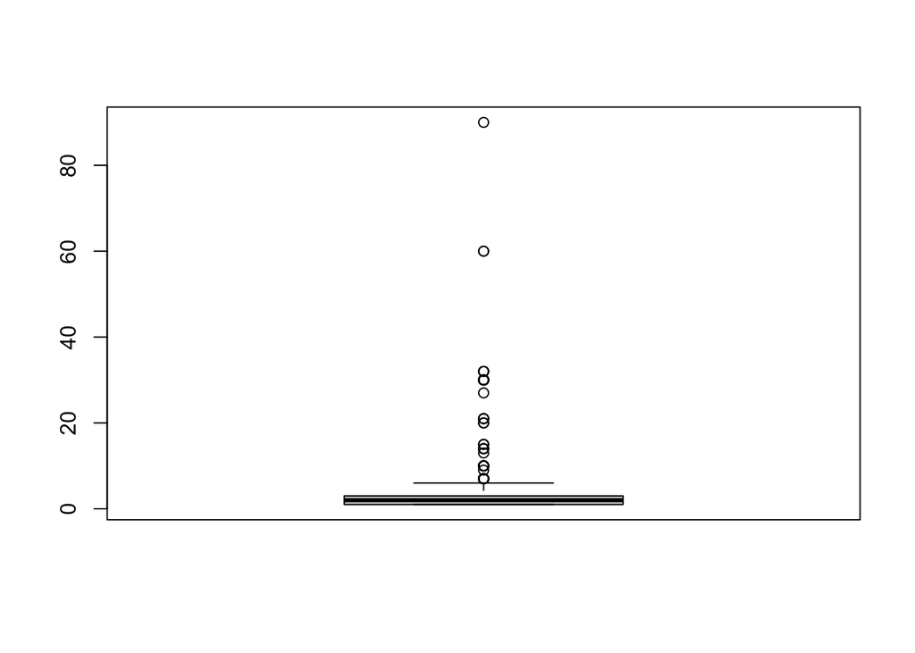

```
##  [1]  7 21 20 20 30 30 30 30 30 32 32 27 32 60 21 30 90  7  7 13 60 21 14 15  7
## [26] 14  9  7 30 14 30 10 10 10  7 10 10  7 15 10 10 10 10  7 30 10 10 10 30 10
## [51]  7  7  7  7  7
```

```r
outliers <- boxplot(new_data$maximum_nights, plot=FALSE)$out
new_data<- new_data[-which(new_data$maximum_nights %in% outliers),]

boxplot(new_data$minimum_nights)$out
```

```r
outliers2 <- boxplot(new_data$minimum_nights, plot=FALSE)$out
outliers2 <- outliers2[outliers2 >= 60]
new_data<- new_data[-which(new_data$minimum_nights %in% outliers2),]
```

We got rid of outliers in the maximum nights because very few properties offered stays for longer than 8000 days, and we removed outliers that in minimum nights becaues the majority of properties did not have a minimum night listed.

Question 4: Mallows CP and Boruta

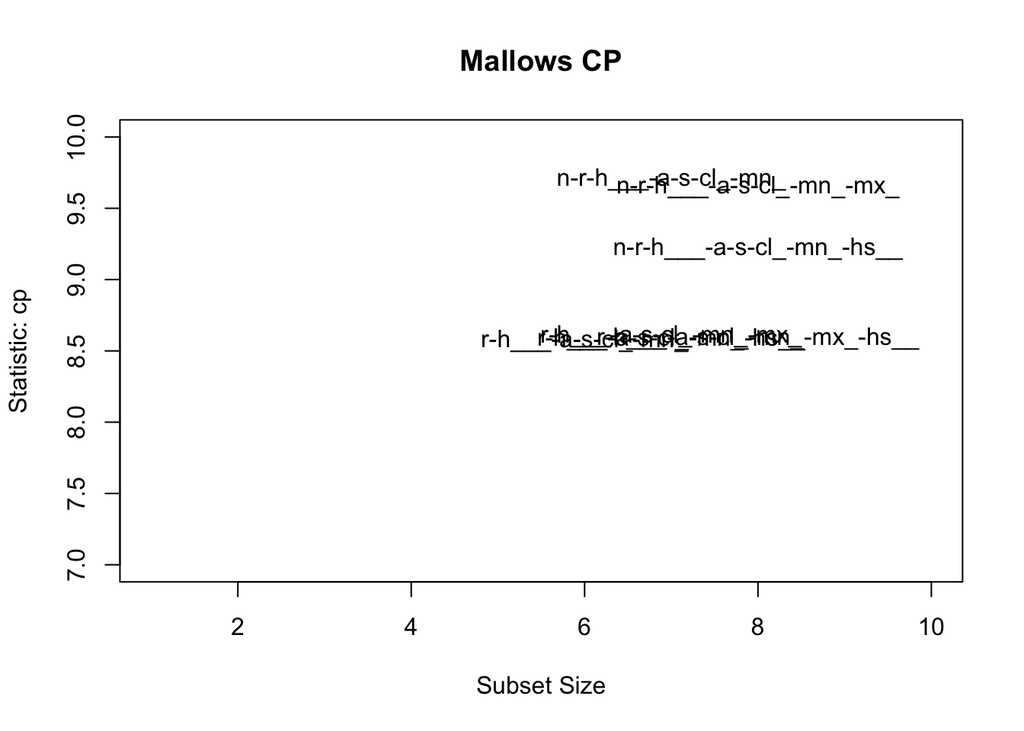

|  | Abbreviation |
| --- | --- |
| number_of_reviews | n |
| review_scores_value | r |
| cancellation_policy | cn_ |
| host_for_x_days | h___ |
| accommodates | a |
| security_deposit | s |
| cleaning_fee | cl_ |
| minimum_nights | mn_ |
| maximum_nights | mx_ |
| host_response_rate | hs__ |

```r
library(car)
library(leaps)
ss=regsubsets(price ~ number_of_reviews + review_scores_value + cancellation_policy
              +host_for_x_days+host_for_x_days+accommodates+price+security_deposit
              +cleaning_fee+minimum_nights+maximum_nights+host_response_rate, data = new_data, method=c("exhaustive"),nbest=3)
subsets(ss,statistic="cp",legend=F,main="Mallows CP",col="steelblue4", ylim = c(7,10))
```

```r
library(Boruta)
Bor <- Boruta(price ~ number_of_reviews + review_scores_value + cancellation_policy
       +host_for_x_days+host_for_x_days+accommodates+price+security_deposit
       +cleaning_fee+minimum_nights+maximum_nights+host_response_rate, data = new_data)
attStats(Bor)
```

|  | meanImp | medianImp | minImp | maxImp | normHits | decision |
| --- | --- | --- | --- | --- | --- | --- |
| price | 52.698721 | 52.683516 | 49.9222110 | 55.670179 | 1.0000000 | Confirmed |
| number_of_reviews | 2.775484 | 2.687759 | 0.8755349 | 5.118265 | 0.7878788 | Confirmed |
| review_scores_value | 1.957627 | 1.923617 | -0.4582375 | 4.437562 | 0.5555556 | Tentative |
| cancellation_policy | 4.066570 | 4.159007 | 1.5195084 | 5.853877 | 0.9696970 | Confirmed |
| host_for_x_days | 7.138396 | 7.135867 | 5.2486910 | 8.808099 | 1.0000000 | Confirmed |
| accommodates | 19.279898 | 19.230696 | 17.6763139 | 21.083855 | 1.0000000 | Confirmed |
| security_deposit | 11.090406 | 11.078491 | 8.4433009 | 13.769410 | 1.0000000 | Confirmed |
| cleaning_fee | 19.613560 | 19.537103 | 17.5854846 | 21.349798 | 1.0000000 | Confirmed |
| minimum_nights | 9.980456 | 9.916352 | 7.9996407 | 12.205362 | 1.0000000 | Confirmed |
| maximum_nights | 3.585839 | 3.607434 | 1.3787452 | 5.680920 | 0.8888889 | Confirmed |

[output cut: 1 more lines]

Based on this, we will keep review_scores_value, host_for_x_days, accommodates, security_deposit, cleaning_fee, and minimum_nights

Question 5: VIF

```r
lmmodel2 <- lm(price~accommodates + security_deposit + cleaning_fee + minimum_nights + review_scores_value + host_for_x_days, data = new_data)
library(car)
vif(lmmodel2)
```

```
##        accommodates    security_deposit        cleaning_fee      minimum_nights
##            1.478831            1.310107            1.909514            1.151057
## review_scores_value     host_for_x_days
##            1.017223            1.068402
```

Multicollinearity shows moderate to high intercorrelations among independent variables; it leads to unstable estimates as it tends to increase the variances of regression coefficients. VIF > 10 indicates presence of multicollinearity. In our example, since all of our values are less than 5~10, we can conclude that these variables don’t have multicollinearity issues.

Question 6: Residuals

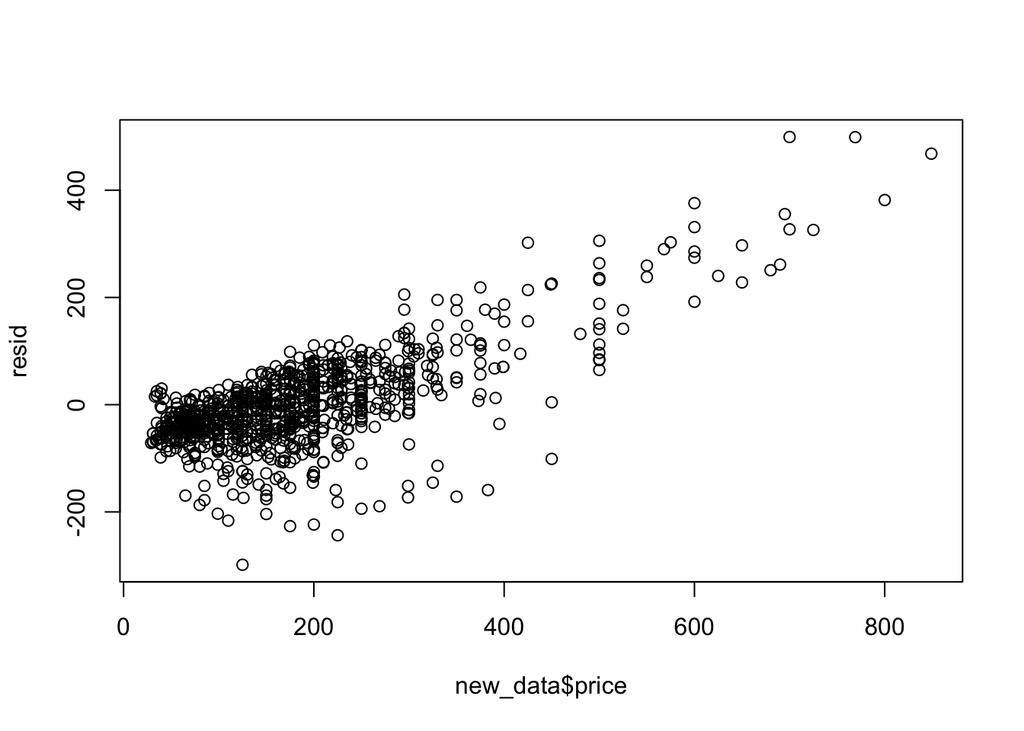

```r
resid <- lmmodel2$residuals
plot(new_data$price, resid)
```

There’s a very clear trend in the residuals which suggests that heteroskedasticity is present.

Question 7: RESET Test

```r
library(lmtest)
resettest(lmmodel2, power = 2, fit = 'regressor', data = new_data)
```

```
##
##  RESET test
##
## data:  lmmodel2
## RESET = 4.7738, df1 = 1, df2 = 927, p-value = 0.02915
```

Question 8: Test for heteroskedasticity

```r
ncvTest(lmmodel2)
```

```
## Non-constant Variance Score Test
## Variance formula: ~ fitted.values
## Chisquare = 486.7784, Df = 1, p = < 2.22e-16
```

```r
bptest(lmmodel2)
```

```
##
##  studentized Breusch-Pagan test
##
## data:  lmmodel2
## BP = 137.13, df = 6, p-value < 2.2e-16
```

With a p-value of 2.22e-16 and 2.2e-16 we can assume that heteroskedasticity is present in our dataset

Question 9: GLS estimator

```r
ehatsq <- residuals(lmmodel2)^2
sighatsq.ols  <-  lm(log(ehatsq)~log(sqrt(accommodates)) + log(security_deposit) + log(cleaning_fee) + log(minimum_nights) + log(review_scores_value) + log(host_for_x_days), data = new_data, na.action = na.exclude)
vari <- exp(fitted(sighatsq.ols))
regmod.fgls <- lm(price~sqrt(accommodates) + security_deposit + cleaning_fee + minimum_nights + review_scores_value + host_for_x_days, data = new_data)
summary(regmod.fgls)
```

```
##
## Call:
## lm(formula = price ~ sqrt(accommodates) + security_deposit +
##     cleaning_fee + minimum_nights + review_scores_value + host_for_x_days,
##     data = new_data)
##
## Residuals:
##     Min      1Q  Median      3Q     Max
## -238.51  -46.54   -9.95   34.33  494.07
##
## Coefficients:
##                       Estimate Std. Error t value Pr(>|t|)
## (Intercept)         -61.889785  34.446909  -1.797   0.0727 .
## sqrt(accommodates)   92.057428   6.415933  14.348  < 2e-16 ***
## security_deposit      0.045856   0.009993   4.589 5.07e-06 ***
## cleaning_fee          0.891053   0.084722  10.517  < 2e-16 ***
## minimum_nights       -3.153093   0.746840  -4.222 2.66e-05 ***
## review_scores_value   7.262940   3.119741   2.328   0.0201 *
## host_for_x_days      -0.020107   0.004871  -4.128 3.98e-05 ***
## ---
## Signif. codes:  0 '***' 0.001 '**' 0.01 '*' 0.05 '.' 0.1 ' ' 1
##
## Residual standard error: 85.29 on 928 degrees of freedom
## Multiple R-squared:  0.4972, Adjusted R-squared:  0.494
## F-statistic:   153 on 6 and 928 DF,  p-value: < 2.2e-16
```

```r
BIC(regmod.fgls, lmmodel1, lmmodel2)
```

|  | df | BIC |
| --- | --- | --- |
| regmod.fgls | 8 | 11015.15 |
| lmmodel1 | 12 | 11103.75 |
| lmmodel2 | 8 | 11035.91 |

```r
AIC(regmod.fgls, lmmodel1, lmmodel2)
```

|  | df | AIC |
| --- | --- | --- |
| regmod.fgls | 8 | 10976.43 |
| lmmodel1 | 12 | 11045.62 |
| lmmodel2 | 8 | 10997.19 |

Our adjusted model has a lower AIC and BIC than either of our previous models so this is the model we will use.

```r
set.seed(1)
row.number <- sample(1:nrow(new_data), 0.75*nrow(new_data))
train = new_data[row.number,]
test = new_data[-row.number,]
dim(train)
```

```
## [1] 701  11
```

```r
dim(test)
```

```
## [1] 234  11
```

```r
sqrt(mean((train$price - predict(regmod.fgls, train)) ^ 2))
```

```
## [1] 84.98123
```

```r
sqrt(mean((test$price - predict(regmod.fgls, test)) ^ 2))
```

```
## [1] 84.9211
```

```r
library(lmvar)
fit= lm(price~sqrt(accommodates) + security_deposit + cleaning_fee + minimum_nights + review_scores_value + host_for_x_days, data = new_data, weights=1/vari,x = TRUE, y = TRUE)
cv.lm(fit, k = 5)
```

```
## Mean absolute error        :  58.98061
## Sample standard deviation  :  2.060053
##
## Mean squared error         :  7369.334
## Sample standard deviation  :  624.5497
##
## Root mean squared error    :  85.78587
## Sample standard deviation  :  3.556476
```